# MY STORY

### **MY JOURNEY**

**MUMBAI,INDIA > BUFFALO,NY > CINCINNATI,OH > LONDON,UK > NEWCASTLE,UK > CINCINNATI,OH**

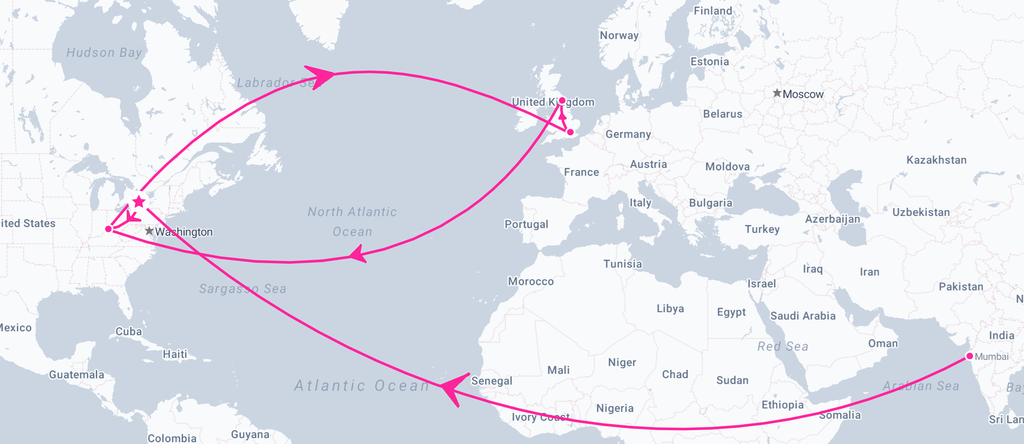

### **Professional Summary**

Seasoned Data Science Professional, Team Leader and Product Owner with over a decades worth of experience in Data Strategy, AI and ML projects and initiatives with true global experience having worked and lived across 3 continents. Holds an MS in Electrical Engineering from the University at Buffalo.

Expertise in predictive analytics, advanced algorithm development, and data-driven decision-making. Proven track record in managing teams, overseeing budgeting, and leading project and feature design from conception through execution.

Skilled in leveraging languages like R, Python, SQL, etc and tools/platforms such as Tableau, PowerBI, Hadoop, Oracle, Snowflake, Databricks, etc to deliver innovative actionable insights or solutions and optimize business processes.

Known for strong leadership and collaboration skills, strategic planning, and the ability to align technical solutions with business objectives.

Adept at collaborating with cross-functional teams to drive impactful outcomes and enhance product value.

Seeking to apply my comprehensive experience, strong leadership and analytical skills, innovative problem-solving, and a commitment to leveraging data for strategic decision-making to advance transformative data and product strategies.

# SKILLS

### **Specializations**

- **Leadership & Management:**
  - Team building
  - Project management
  - Mentorship
  - Cross-functional collaboration.
- **Advanced Analytics:**
  - Machine learning
  - statistical modeling
  - Predictive analytics
  - Deep learning
  - Generative Synthetic Data Monetization
- **Business Acumen:**
  - Data strategy
  - Business intelligence
  - Stakeholder management
  - ROI optimization
- **Communication Skills:**
  - Technical writing
  - Presentation
  - Storytelling with data
  - Stakeholder alignment

### **Tools**

- **DataBases:**
  - Hive / Hadoop
  - Oracle
  - Teradata
  - Snowflake
  - DataBricks
- **BI Tools:**
  - Tableau
  - Microstrategy
  - Power BI
  - Business Objects
  - Markdown
  - Shiny
- **Programming Languages:**
  - R
  - Python
  - SQL
  - SAS Enterprise
  - SPARK/PIG

# WORK EXPERIENCE

### **Vantiv / Worldpay / FIS**

- **Locations**
  - Cincinnati, OH
  - London UK
- **Roles**:
  - Data Scientist, September 2015 – August 2018
  - Senior Data Scientist, August 2018 - Present
- **Responsibilities**:
  - Spearheaded the development and implementation of Network Strategy and Routing Initiatives (~$100mil).
  - Provided Merchant Analytics including RFP evaluations, PL analytics and Strategy Development
  - Managed and supported Sales prospects resulting in data-supported sales increase of ~15%
  - Led a team of data scientists to build and manage a Merchant Attrition Monitoring System (Reduced Merchant Attrition by 25%)
  - Supported multiple Marketing Campaigns with complex collaborative filters to provide data backed product suggestions and monitoring campaign success.
  - Led a team of data scientists to build and manage Monthly Pricing Maintenance (Increased Merchant Revenue by $15 mil each year)
  - Worked with a cross-functional team to develop Merchant Risk Analytics (Reduced Fraud/Charge-back)
  - Worked with a cross-functional team to support Customer Life-cycle Management. (Tremendously improved customer on-boarding experience)
  - Collaborated with product/engineering and sales teams to develop Data Monetization Streams (with Generative Synthetic Data Generation)
  - Conducted training sessions and mentored junior data scientists, fostering a culture of continuous learning and innovation.
  - Presented findings to C-suite executives, translating complex technical insights into actionable business strategies.
- **Key Achievements**:
  - Recipient of the “Excellence in Innovation” award for scaling and innovating network strategy and routing initiatives that boosted revenue by 200%.
  - Successfully managed multiple projects with budgets exceeding $500K.

### **Integral Information Systems**

- **Locations**
  - Buffalo, NY
- **Roles**:
  - Senior Business Data Analyst, May 2014 – September 2015
- **Responsibilities**:
  - Collaborated with Multi-Industry Clients to provide Business support including ad-hoc reporting as well Quality Assurance support
  - Designed and developed dashboards and reports to bring deeper insight into business operations and finances
  - Managed and supported Sales prospects/ Create POCs
  - Design and build forecasting into the latest product (FTEPRIME™) (Predictive Analytic techniques)

### **Accenture**

- **Locations**
  - Mumbai, India
- **Roles**:
  - Consultant, 2012- 2013
- **Responsibilities**:
  - Consulted for major US Retailers like KOHLS, BESTBUY, WALGREENS, etc to develop and enhance their data strategy.
  - Helped design and build their Stores, Loyalty customer and e-commerce Datalakes as well as define Business Use Cases and BI Reporting Needs and Methodologies.
  - Developed Schemas and Built Teradata tables and SLVs as SQL/DataWarehousing SME (Database Architect)
  - Acted as Microstrategy architect (1000+ attributes and metrics plus custom filters) and Microstrategy SQL web dashboard developer (BI Reporting)
  - Led and reviewed most team-customer communications to ensure a level of professionalism and propriety as well as translate business use cases to the relevant delivery teams as needed.
  - Supported the development of English Language Skills by training several colleagues and juniors to help facilitate better communication protocols.

# EDUCATION

### **M.S. in Electrical Engineering**

- **University at Buffalo**
- The State University of New York

[figure not shown]

### Diploma

[figure not shown]

### **B.E. in Electronics and Telecommunications**

- **K.J. Somaiya College of Engineering**
- Mumbai University

[figure not shown]